# Alternative splicing changes in response to HNRNPH titration

Mario Keller

Faculty of Biological Sciences, Goethe University Frankfurt

15 June 2023

```r
library(tidyverse)
library(knitr)
library(ggpubr)
library(ggsci)
library(viridis)
library(ComplexHeatmap)
library(circlize)
```

```r
myTheme <- theme_bw() +
    theme(axis.text = element_text(size = 14, colour="black"),
          axis.title = element_text(size=16, colour="black"),
          axis.ticks=element_line(color="black"),
          axis.ticks.length=unit(.15, "cm"),
          panel.border=element_rect(color="black", fill = NA),
          panel.background = element_blank(),
          plot.background = element_blank(),
          legend.text = element_text(size=12),
          legend.position = "none")
```

```r
projectDir <- "/Users/mariokeller/projects/HNRNPH_project/Tretow_et_al_2023"

majiqDir <- paste0(projectDir,"/2_MAJIQ_AS_analysis")
```

# 1 Background

RNA-seq data of HNRNPH titration experiments was analyzed using the MAJIQ framework to detect differentially regulated alternative splicing (AS) events. Data included 7 knockdown experiments with a matched control as well as 3 overexpression experiments with a matched control. *majiq build* in combination with the human GENCODE annotation v39 was used to generate the splicegraph and detect so-called local splicing varions (LSVs). *majiq deltapsi* was used for PSI and $\Delta$PSI quantifications between knockdown and overexpression experiments and their matched controls. *voila modulize* was used for the inference of binary AS events (e.g. cassette exon and intron retention). The output of *voila modulize* served as input for this report.

# 2 Data

The MAJIQ Modulizer output is loaded from a RDS-File, created with *MAJIQ_Modulizer_output_to_rds.R*. It is a list containing for each of the 14 AS event classes a data.frame.

```r
MAJIQ_binaryEvents <- readRDS(paste0(majiqDir,"/rds_files/MAJIQ_binaryEvents.rds"))
```

# 3 Identification of regulated AS events

The identification of regulated AS events is a trade-off between an overly strict approach, in which actual regulated events are lost, and an overly relaxed approach, which introduces false positives.

The 14 AS event classes harbor for each event either two or four junctions (retained introns are treated like junctions). For instance, a cassette exon event is made up by two pairs of junctions. One pair includes the first inclusion junction (C1_A) and the skipping junction (C1_C2) and the second pair the second inclusion junction (C2_A) and the skipping junction (C2_C1). Intron retention events on the other hand are only made up by one pair of junctions, namely the intron itself (C1_C2_intron or C2_C1_intron) and the juntion removing the intron (C1_C2_spliced or C2_C1_spliced). Each junction is represented as a row in the underlying data.frame of each event class.

The workflow for the identification of regulated AS events is executed for each of the 10 pairwise comparisons.

For AS event classes with only one pair of junctions, an events is considered as regulated if:

- Both junctions have P(|$\Delta$PSI| $\ge$ 0.02) $\ge$ 0.9.
- Both junctions have |$\Delta$PSI| $\ge$ 0.025.
- The two junctions have inverse regulation.
- The lower |$\Delta$PSI| must be at least 50% of the higher |$\Delta$PSI|.

For AS event classes with two pairs of junctions an events is considered as regulated if:

- For at least one pair of junctions both junctions have P(|$\Delta$PSI| $\ge$ 0.02) $\ge$ 0.9.
- All four junctions have |$\Delta$PSI| $\ge$ 0.025.
- For each pair the two junctions have inverse regulation (except for the multi exon spanning class*).
- For each pair the lower |$\Delta$PSI| must be at least 50% of the higher |$\Delta$PSI|.

*For the multi exon spanning class the the $\Delta$PSI of the proximal junctions is the same as the $\Delta$PSI of the distal junctions. Likely a bug as they could have provided the correct |$\Delta$PSI|.

```r
#Contains the prefix of the 10 pairwise comparisons
comparisons <- c("KD_10000.KD_Contr", "KD_05000.KD_Contr", "KD_01000.KD_Contr",
                 "KD_00500.KD_Contr", "KD_00250.KD_Contr","KD_00100.KD_Contr",
                 "KD_00050.KD_Contr", "OE_00600.OE_Contr", "OE_01000.OE_Contr",
                 "OE_02500.OE_Contr")

# Iterate over each of the 14 event classes
regulatedEvents <- lapply(names(MAJIQ_binaryEvents), function(eventClass){

    # Extract the data.frame of the event class from the list
    eventsClassDf <- MAJIQ_binaryEvents[[eventClass]]

    # Iterate over each of the 10 pairwise comparisons
    lapply(comparisons, function(comparison){

        # Define the columns used for the filtering
        probCol <- paste0(comparison,"_probability_changing")
        dpsiCol <- paste0(comparison,"_median_dpsi")

        # Create a reduced  data.frame
        df <- eventsClassDf[,c("gene_name", "module_id", "event_id",
                               "lsv_id", probCol, dpsiCol)]

        # Store the event_id of the events lacking information for at least one junction
        notFullyQuantified <- df %>%
            dplyr::filter(., is.na(get(probCol)) | is.na(get(dpsiCol))) %>%
            pull(event_id) %>% unique

        # This block performs a pre-filtering and checks which of the events m
        #   match the mentioned criterions
        df <- df %>%
            dplyr::filter(!event_id %in% notFullyQuantified) %>%
            dplyr::filter(., !lsv_id == "") %>%
            group_by(event_id, lsv_id) %>%
            summarise(gene_name = unique(gene_name),
                      module_id = unique(module_id),
                      regulated= sum(get(probCol) >= 0.9) == 2,
                      change = sum(abs(get(dpsiCol)) >= 0.025) == 2,
                      opposite = sum(sign(get(dpsiCol))) == 0,
                      fraction = sum(abs(get(dpsiCol)/max(abs(get(dpsiCol)))) >= 0.5) == 2) %>%
        summarise(gene_name=unique(gene_name), module_id=unique(module_id),
                  regulated = any(regulated),
                  change=all(change),
                  opposite=all(opposite),
                  fraction=all(fraction))

        # This block filters out events not matching the criterions. As mentioned
        #   the multi exon spanning events can never meet the "inverse regulation"
        #   criterion, which is why this criterion is left out for them.
        if(eventClass == "multi_exon_spanning"){
            df <- df %>% dplyr::filter(regulated, change, fraction) %>%
                dplyr::select(gene_name, module_id, event_id)
        } else {
            df <- df %>% dplyr::filter(regulated, change, opposite, fraction) %>%
                dplyr::select(gene_name, module_id, event_id)
        }

        # This block creates for each comparison the final data.frame. The
        #   nrow(df) == 0 command handles the rare cases where a comparison has
        #   no regulated event for an AS event class.
        if(nrow(df) == 0){
            df <- data.frame(eventClass=character(), gene_name=character(),
                             module_id=character(), event_id=character(),
                             placeholder=logical())
            colnames(df)[5] <- comparison
        } else {
            df$placeholder <- TRUE
            colnames(df)[4] <- comparison
            df <- cbind(eventClass = eventClass, df)
        }

        return(df)
    }) %>%
        purrr::reduce(full_join, by=c("eventClass", "gene_name",
                                      "module_id", "event_id")) %>%
        replace(is.na(.), FALSE)
}) %>% bind_rows()
```

The resulting data.frame provides for each event the event class, the name of the underlying gene, the module_id and the event_id. In addition, for each comparison a column is added that indicates via TRUE/FALSE whether the event is regulated in that comparison.

Shown are the 10 random rows:

```r
set.seed(123)
regulatedEvents %>%
    slice_sample(n=10) %>%
    kable(., "html") %>%
    kableExtra::kable_styling("striped") %>%
    kableExtra::scroll_box(height="300px", width = "94%")
```

| eventClass | gene_name | module_id | event_id | KD_10000.KD_Contr | KD_05000.KD_Contr | KD_01000.KD_Contr | KD_00500.KD_Contr | KD_00250.KD_Contr | KD_00100.KD_Contr | KD_00050.KD_Contr | OE_00600.OE_Contr | OE_01000.OE_Contr | OE_02500.OE_Contr |
| --- | --- | --- | --- | --- | --- | --- | --- | --- | --- | --- | --- | --- | --- |
| cassette | ZNF708 | ENSG00000182141.10_1 | ENSG00000182141.10_1_CE_1 | FALSE | TRUE | FALSE | FALSE | FALSE | FALSE | FALSE | FALSE | FALSE | FALSE |
| cassette | LRRC45 | ENSG00000169683.8_5 | ENSG00000169683.8_5_CE_1 | FALSE | FALSE | TRUE | FALSE | FALSE | FALSE | FALSE | FALSE | FALSE | FALSE |
| cassette | ULK3 | ENSG00000140474.14_1 | ENSG00000140474.14_1_CE_2 | TRUE | FALSE | FALSE | FALSE | FALSE | FALSE | FALSE | FALSE | FALSE | FALSE |
| cassette | BBIP1 | ENSG00000214413.9_1 | ENSG00000214413.9_1_CE_2 | FALSE | FALSE | FALSE | FALSE | FALSE | TRUE | FALSE | FALSE | FALSE | FALSE |
| cassette | FIP1L1 | ENSG00000145216.16_3 | ENSG00000145216.16_3_CE_1 | TRUE | TRUE | FALSE | FALSE | FALSE | FALSE | FALSE | FALSE | FALSE | FALSE |
| alt5prime | RSRC1 | ENSG00000174891.14_1 | ENSG00000174891.14_1_A5_1 | TRUE | FALSE | FALSE | FALSE | FALSE | FALSE | FALSE | FALSE | FALSE | FALSE |
| alternate_first_exon | STK32C | ENSG00000165752.17_1 | ENSG00000165752.17_1_afe_2 | TRUE | FALSE | FALSE | FALSE | FALSE | FALSE | FALSE | FALSE | FALSE | FALSE |
| p_alt3prime | PHF23 | ENSG00000040633.13_2 | ENSG00000040633.13_2_pA3_1 | TRUE | FALSE | FALSE | FALSE | FALSE | FALSE | FALSE | FALSE | FALSE | FALSE |
| alternate_last_exon | IKBIP | ENSG00000166130.15_1 | ENSG00000166130.15_1_ale_1 | TRUE | FALSE | FALSE | FALSE | FALSE | TRUE | FALSE | FALSE | FALSE | FALSE |
| alternate_last_exon | ZSWIM7 | ENSG00000214941.8_4 | ENSG00000214941.8_4_ale_1 | TRUE | FALSE | FALSE | FALSE | FALSE | FALSE | FALSE | FALSE | FALSE | FALSE |

In the following, I determined for each comparison the number of regulated events per AS event class:

```r
regulatedEventFrequencies <- regulatedEvents %>%
    pivot_longer(cols=ends_with("_Contr"),
                 names_to="comparison",
                 values_to="regulated") %>%
    dplyr::filter(regulated) %>%
    mutate(comparison = factor(strsplit(comparison, ".", fixed=T) %>%
                                   sapply(., "[[", 1),
                               levels=strsplit(comparisons, ".", fixed=T) %>%
                                   sapply(., "[[", 1))) %>%
    mutate(eventClass = factor(eventClass)) %>%
    dplyr::count(eventClass, comparison, name="Frequency", .drop=FALSE)

regulatedEventFrequencies %>%
          pivot_wider(., names_from=comparison, values_from=Frequency) %>%
    kable(., "html") %>%
    kableExtra::kable_styling("striped") %>%
    kableExtra::scroll_box(height="300px", width = "94%")
```

| eventClass | KD_10000 | KD_05000 | KD_01000 | KD_00500 | KD_00250 | KD_00100 | KD_00050 | OE_00600 | OE_01000 | OE_02500 |
| --- | --- | --- | --- | --- | --- | --- | --- | --- | --- | --- |
| alt3and5prime | 0 | 0 | 1 | 1 | 0 | 1 | 0 | 0 | 0 | 0 |
| alt3prime | 33 | 25 | 12 | 7 | 3 | 3 | 3 | 4 | 1 | 4 |
| alt5prime | 46 | 38 | 23 | 13 | 6 | 6 | 5 | 1 | 2 | 8 |
| alternate_first_exon | 71 | 44 | 22 | 7 | 9 | 7 | 4 | 1 | 3 | 8 |
| alternate_last_exon | 63 | 31 | 24 | 9 | 4 | 3 | 6 | 3 | 3 | 6 |
| alternative_intron | 266 | 71 | 16 | 3 | 3 | 0 | 0 | 4 | 9 | 13 |
| cassette | 335 | 251 | 135 | 82 | 40 | 31 | 14 | 11 | 27 | 62 |
| multi_exon_spanning | 245 | 172 | 72 | 47 | 19 | 14 | 10 | 13 | 24 | 35 |
| mutually_exclusive | 9 | 4 | 0 | 0 | 0 | 0 | 0 | 0 | 0 | 0 |
| p_alt3prime | 11 | 6 | 4 | 1 | 0 | 1 | 0 | 0 | 0 | 0 |
| p_alt5prime | 6 | 4 | 2 | 2 | 1 | 0 | 0 | 1 | 0 | 0 |
| p_alternate_first_exon | 8 | 3 | 0 | 1 | 3 | 0 | 0 | 0 | 2 | 0 |
| p_alternate_last_exon | 11 | 10 | 1 | 0 | 0 | 0 | 1 | 1 | 2 | 1 |
| tandem_cassette | 16 | 6 | 1 | 1 | 0 | 0 | 0 | 0 | 0 | 2 |

```r
eventsOfInterest <- c("cassette", "alternative_intron", "multi_exon_spanning",
                      "alternate_first_exon", "alternate_last_exon",
                      "alt5prime", "alt3prime", "other")

# Merge less interesting AS event classes into "other"
regulatedEventFrequencies <- regulatedEventFrequencies %>%
    add_row(
        regulatedEventFrequencies %>%
            group_by(comparison) %>%
            filter(!eventClass %in% eventsOfInterest) %>%
            summarise(eventClass="other", Frequency = sum(Frequency)) %>%
            select(eventClass, comparison, Frequency)) %>%
    filter(., eventClass %in% eventsOfInterest) %>%
    mutate(eventClass=factor(eventClass, levels=rev(eventsOfInterest)))
```

For the generation of a stacked barchart, less interesting AS event classes were combined into a single class called “other”.

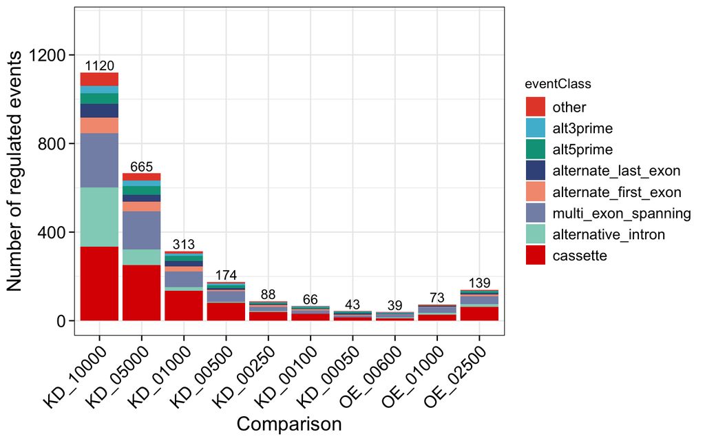

```r
# A stacked barchart is created. Stacks are the 8 AS event classes. Total
#   number of events per stacked bar is shown above each bar
regulatedEventFrequencies %>%
    ggplot(., aes(x=comparison, y=Frequency, fill=eventClass)) +
    geom_col() +
    labs(x="Comparison", y= "Number of regulated events") +
    scale_fill_npg() +
    geom_text(aes(label = stat(y), group = comparison), stat = 'summary',
              fun = sum, vjust = -.25) +
    scale_y_continuous(limits=c(0,1350), breaks=seq(0,1400,400)) +
    myTheme +
    theme(axis.text.x = element_text(angle=45, vjust = 1, hjust = 1),
          legend.position = "right")
```

It can be readily seen that as the strength of knockdown and overexpression increases, the number of regulated alternative splicing events also increases. The highest number of regulated events is observed for the strongest knockdown with 1120. The dominant class of events is the cassette exon class.

# 4 Overlap of regulated events between comparisons

The overlap of regulated events between the 10 pairwise comparisons was determined by generating a matrix (rows = events, columns = comparisons) and encoding regulation with 1 (TRUE) and no regulation with 0 (FALSE). The matrix was used to generate a Heatmap showing the overlap.

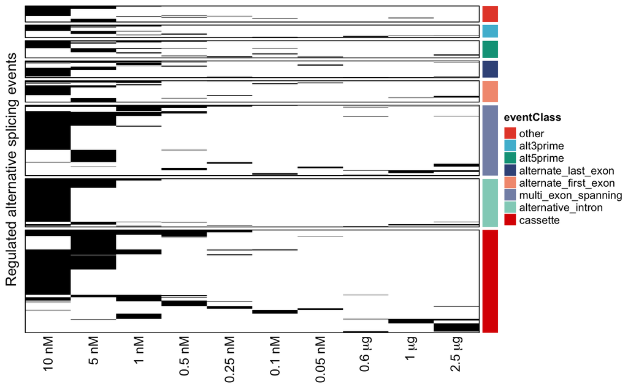

```r
# Extract the TRUE/FALSE columns for the 10 comparisons
regulationMatrix <- regulatedEvents[,5:14] %>% as.matrix()

#Turn TRUEs into 1s and FALSEs into 0s
regulationMatrix[regulationMatrix==TRUE] <- 1
regulationMatrix[regulationMatrix==FALSE] <- 0

# Column names are adjusted according to the used siRNA concentrations (knockdown)
#   and the amount of expression vector (overexpression)
colNames <- c("10 nM", "5 nM", "1 nM", "0.5 nM", "0.25 nM", "0.1 nM", "0.05 nM",
              expression(0.6~mu*g), expression(1~mu*g), expression(2.5~mu*g))

#Set the colors
myCols = structure(c("white", "black"), names = c("0", "1"))

# Prepare the AS event class information for the row annotation
class <- regulatedEvents$eventClass
class[!class %in% eventsOfInterest] <- "other"
class <- factor(class, levels=rev(eventsOfInterest))

row_ha = rowAnnotation(eventClass = class,
                       col=list(eventClass=structure(ggsci::pal_npg()(8),
                                                     names=levels(class))),
                       show_annotation_name=F)

# A two-color heatmap is created, whereby each rows is an AS event. Rows
#   are grouped by the AS event class and additionally clustered within each
#   group.
set.seed(123)
Heatmap(regulationMatrix, col=myCols, name="regulated", border=TRUE,
        cluster_rows = TRUE, cluster_columns = FALSE, cluster_row_slices=FALSE,
        show_row_dend = FALSE, right_annotation = row_ha, row_split=class,
        use_raster = TRUE, raster_quality = 10, raster_by_magick = FALSE,
        column_labels=colNames, show_heatmap_legend = FALSE,
        row_title="Regulated alternative splicing events")
```

# 5 Focus on cassette exon, alternative last exon and intron retention events

After analyzing all AS event classes, our focus was on cassette exon (CE), alternative last exon (ALE) and intron retention (IR) events.

We consider events in these classes that meet the following criteria:

- Quantified in all 10 comparisons (we need $\Delta$PSI values for all of them)
- Regulated in one of the two strongest knockdown experiments and/or in the two strongest overexpression experiments

In addition, we needed to define the “inclusion levels” of the events in these classes, meaning the inclusion levels of the alternative exon (CE events), of the first/proximal alternative last exon (ALE events) and the intron (IR events). For thir purpose, we define for each event a representative junction, whose PSI and $\Delta$PSI quantifications will be used in all upcoming analyses.

For CE events it is either the first (C1_A) or second (C2_A) inclusion junction. For each event we choose the one that has the highest $\Delta$PSI in the two strongest knockdown and overexpression experiments.

For ALE events the representative junction is the proximal junction and for IR events the intron itself (C1_C2_intron or C2_C1_intron).

```r
# Extract IDs of potential candidates (regulated in at least one of the
#   two strongest knockdown and overexpression experiments)
candidateIDsCEs <- regulatedEvents %>%
    dplyr::filter(eventClass == "cassette") %>%
    dplyr::filter(KD_10000.KD_Contr | KD_05000.KD_Contr |
                      OE_01000.OE_Contr | OE_02500.OE_Contr) %>%
    pull(event_id)

# Take MAJIQ output for all events of the class (4 rows per event)
regulatedCEs <- MAJIQ_binaryEvents$cassette

# Fetch IDs of events not quantified in all comparisons
notFullyQuantifiedCEs <- regulatedCEs$event_id[
    apply(regulatedCEs, 1, function(row){any(is.na(row))})
    ] %>%
    unique

# Filter the events, determine the representative junction and keep for each
#   event only the row of the representative junction. slice(1) is for the case
#   that both junctions have the maximum dPSI (only the first one is used).
regulatedCEs <- regulatedCEs %>%
    dplyr::filter(!event_id %in% notFullyQuantifiedCEs) %>%
    dplyr::filter(event_id %in% candidateIDsCEs) %>%
    dplyr::filter(junction_name %in% c("C1_A", "C2_A")) %>%
    rowwise %>%
    mutate(dpsiMax = max(abs(KD_10000.KD_Contr_median_dpsi),
                         abs(KD_05000.KD_Contr_median_dpsi),
                         abs(OE_01000.OE_Contr_median_dpsi),
                         abs(OE_02500.OE_Contr_median_dpsi))) %>%
    ungroup %>%
    group_by(event_id) %>%
    dplyr::filter(dpsiMax == max(dpsiMax)) %>%
    slice(1) %>%
    ungroup %>%
    arrange(event_id)

################################################################################

# Extract IDs of potential candidates (regulated in at least one of the
#   two strongest knockdown and overexpression experiments)
candidateIDsALEs <- regulatedEvents %>%
    dplyr::filter(eventClass == "alternate_last_exon") %>%
    dplyr::filter(KD_10000.KD_Contr | KD_05000.KD_Contr |
                      OE_01000.OE_Contr | OE_02500.OE_Contr) %>%
    pull(event_id)

# Take MAJIQ output for all events of the class (2 rows per event)
regulatedALEs <- MAJIQ_binaryEvents$alternate_last_exon

# Fetch IDs of events not quantified in all comparisons
notFullyQuantifiedALEs <- regulatedALEs$event_id[
    apply(regulatedALEs, 1, function(row){any(is.na(row))})
    ] %>% unique

# Filter the events, determine the representative junction and keep for each
#   event only the row of the representative junction.
regulatedALEs <- regulatedALEs %>%
    dplyr::filter(!event_id %in% notFullyQuantifiedALEs) %>%
    dplyr::filter(event_id %in% candidateIDsALEs) %>%
    dplyr::filter(junction_name == "Proximal") %>%
    rowwise %>%
    mutate(dpsiMax = max(abs(KD_10000.KD_Contr_median_dpsi),
                         abs(KD_05000.KD_Contr_median_dpsi),
                         abs(OE_01000.OE_Contr_median_dpsi),
                         abs(OE_02500.OE_Contr_median_dpsi))) %>%
    ungroup %>%
    group_by(event_id) %>%
    dplyr::filter(dpsiMax == max(dpsiMax)) %>%
    ungroup %>%
    arrange(event_id)

#################################################################################

# Extract IDs of potential candidates (regulated in at least one of the
#   two strongest knockdown and overexpression experiments)
candidateIDsIRs <- regulatedEvents %>%
    dplyr::filter(eventClass == "alternative_intron") %>%
    dplyr::filter(KD_10000.KD_Contr | KD_05000.KD_Contr |
                      OE_01000.OE_Contr | OE_02500.OE_Contr) %>%
    pull(event_id)

# Take MAJIQ output for all events of the class (2 rows per event)
regulatedIRs <- MAJIQ_binaryEvents$alternative_intron

# Fetch IDs of events not quantified in all comparisons
notFullyQuantifiedIRs <- regulatedIRs$event_id[
    apply(regulatedIRs, 1, function(row){any(is.na(row))})
    ] %>% unique

# Filter the events, determine the representative junction and keep for each
#   event only the row of the representative junction.
regulatedIRs <- regulatedIRs %>%
    dplyr::filter(!event_id %in% notFullyQuantifiedIRs) %>%
    dplyr::filter(event_id %in% candidateIDsIRs) %>%
    dplyr::filter(junction_name %in% c("C1_C2_intron", "C2_C1_intron")) %>%
    rowwise %>%
    mutate(dpsiMax = max(abs(KD_10000.KD_Contr_median_dpsi),
                         abs(KD_05000.KD_Contr_median_dpsi),
                         abs(OE_01000.OE_Contr_median_dpsi),
                         abs(OE_02500.OE_Contr_median_dpsi))) %>%
    ungroup %>%
    group_by(event_id) %>%
    dplyr::filter(dpsiMax == max(dpsiMax)) %>%
    ungroup %>%
    arrange(event_id)
```

Here are the final set sizes:

- CE events: 447
- ALE events: 71
- IR events: 276

## 5.1 Cassette exons

For the final CE events a $\Delta$PSI Heatmap was generated to visualize the change in exon inclusion levels throughout the HNRNPH titration.

[figure not shown]

```r
# Fetch the dPSI columns via the column suffix
dpsiMatrix <- regulatedCEs %>%
    select(., ends_with("median_dpsi"))

# Use only the prefix of the column names
colnames(dpsiMatrix) <- strsplit(colnames(dpsiMatrix), ".", fixed=TRUE) %>%
    sapply(., "[[", 1)

# Define colors
myCols <- colorRamp2(c(-0.3, -0.15, 0, 0.15, 0.3), RColorBrewer::brewer.pal(n = 5, name = "BrBG"))

set.seed(123)
Heatmap(dpsiMatrix, col = myCols, row_km=3, name = "dPSI", show_row_dend = FALSE,
        show_column_dend = FALSE, border=TRUE, row_title = NULL)
```

The majority of cassette exons shows increased inclusion in the stronger knockdowns, confirming the hypothesis that HNRNPH acts as a repressor of cassette exons.

## 5.2 Alternative last exons

For the final ALE events a $\Delta$PSI Heatmap was generated to visualize the change in the inclusion level of the proximal alternative last exon throughout the HNRNPH titration.

[figure not shown]

```r
# Fetch the dPSI columns via the column suffix
dpsiMatrix <- regulatedALEs %>%
    select(., ends_with("median_dpsi"))

# Use only the prefix of the column names
colnames(dpsiMatrix) <- strsplit(colnames(dpsiMatrix), ".", fixed=TRUE) %>%
    sapply(., "[[", 1)

set.seed(123)
Heatmap(dpsiMatrix, col = myCols, row_km=3, name = "dPSI", show_row_dend = FALSE,
        show_column_dend = FALSE, border=TRUE, row_title = NULL)
```

Similar to the cassette exons, the inclusion of the first alternative last exon is increased upon knockdown, indicating that HNRNPH promotes the inclusion of the downstream (second) alternative last exon under control conditions.

## 5.3 Retained introns

For the final IR events a $\Delta$PSI Heatmap was generated to visualize the change in the inclusion levels throughout the HNRNPH titration.

[figure not shown]

```r
# Fetch the dPSI columns via the column suffix
dpsiMatrix <- regulatedIRs %>%
    select(., ends_with("median_dpsi"))

# Use only the prefix of the column names
colnames(dpsiMatrix) <- strsplit(colnames(dpsiMatrix), ".", fixed=TRUE) %>%
    sapply(., "[[", 1)

set.seed(123)
Heatmap(dpsiMatrix, col = myCols, row_km=3, name = "dPSI", show_row_dend = FALSE,
        show_column_dend = FALSE, border=TRUE, row_title = NULL)
```

Similar to the cassette exons, the inclusion of the retained introns is is increased upon knockdown, indicating that HNRNPH is required for their removal under control conditions.

# 6 Non-regulated cassette exon events

For upcoming analyses control (non-regulated) CE events had to be identified.

```r
# Filter for junctions that match the criterion and check if all four
#   junctions of a CE event survived the filtering
nonRegulatedCEs <- MAJIQ_binaryEvents$cassette %>%
    dplyr::filter(if_all(ends_with("_median_dpsi"), ~ abs(.) <= 0.025)) %>%
    dplyr::count(event_id, name="Frequency") %>%
    dplyr::filter(Frequency==4)

# Add the module_id to the data.frame
nonRegulatedCEs <- left_join(nonRegulatedCEs,
                             MAJIQ_binaryEvents$cassette %>%
                                 dplyr::select(module_id, event_id) %>%
                                 dplyr::distinct(),
                             by="event_id")

# Select only one non-regulated CE per AS module
nonRegulatedCEs <- nonRegulatedCEs %>%
    group_by(module_id) %>%
    arrange(event_id) %>%
    slice(1) %>%
    pull(event_id)

# Create the final data.frame by filtering for the IDs of non-regulated CEs and
#   use the row of the first inclusion junction (C1_A) as representative.
nonRegulatedCEs <-  MAJIQ_binaryEvents$cassette %>%
    dplyr::filter(event_id %in% nonRegulatedCEs) %>%
    dplyr::filter(junction_name == "C1_A")
```

The final set size of non-regulated CE events is 1152.

# 7 Output

The final sets of regulated CE, ALE and IR events are stored in RDS-Files that will be used in other analyses (e.g. DRC fitting). In addition, the data.frame with all regulated AS events (the TRUE/FALSE data.frame) and the non-regulated CE events are also stored in RDS-Files.

```r
saveRDS(regulatedCEs, paste0(majiqDir, "/rds_files/regulatedCEs.rds"))
saveRDS(regulatedALEs, paste0(majiqDir, "/rds_files/regulatedALEs.rds"))
saveRDS(regulatedIRs, paste0(majiqDir, "/rds_files/regulatedIRs.rds"))

saveRDS(regulatedEvents, paste0(majiqDir, "/rds_files/regulatedEvents.rds"))

saveRDS(nonRegulatedCEs, paste0(majiqDir, "/rds_files/nonregulatedCEs.rds"))
```